# Ocorrências criminais no Brasil

Criado por: Felipe Menino Carlos e Weslei Luiz de Paula Pinto

Data: 14 de novembro de 2018

## Sobre

Esta análise foi criada como um dos trabalhos da matéria de Laboratório de bancos de dados, da Fatec SJC.

Os dados aqui utilizados foram disponibilizados [aqui](http://dados.gov.br/dataset/sistema-nacional-de-estatisticas-de-seguranca-publica), pelo Sistema Nacional de Estatísticas de Segurança Pública e Justiça Criminal (**SINESPJC**).

Todos os scripts utilizados, tanto para a análise quanto para a aquisição dos dados está disponível no [Github](https://github.com/M3nin0/ocorrencias-brasil), estes foram criados para tornar este documento mais simples.

## Análise dos dados

Todo o processo da análise destes dados foram documentados para a fácil replicão. O processo seguido utiliza ideias gerais de análise exploratória de dados.

Vamos começar carregando os scripts criados para facilitar a análise.

```r
options(warn = -1) # Sem warnings

suppressMessages(library(tidyverse));
source('tool/r/data_utils.R');
source('tool/r/filter_data.R');
source('tool/r/groups.R');
```

Primeiro vamos tratar de apenas um ano, para depois expandir a análise para todos os dados disponíveis. O ano escolhido foi 2013.

```r
year2013 <- readSpecificYear(2013);
```

Com os dados carregados vamos olhar como é sua estrutura.

```r
head(year2013, 5);
```

| regiao | sigla_uf | uf | cod_uf | municipio | tipo_crime | mes | mes_ano | ocorrencias |
| --- | --- | --- | --- | --- | --- | --- | --- | --- |
| CENTRO-OESTE | DF | Distrito Federal | 530010801 | Brasília | Estupro | 1 | 01/2013 | 4 |
| CENTRO-OESTE | DF | Distrito Federal | 530010801 | Brasília | Estupro | 2 | 02/2013 | 5 |
| CENTRO-OESTE | DF | Distrito Federal | 530010801 | Brasília | Estupro | 3 | 03/2013 | 1 |
| CENTRO-OESTE | DF | Distrito Federal | 530010801 | Brasília | Estupro | 4 | 04/2013 | 6 |
| CENTRO-OESTE | DF | Distrito Federal | 530010801 | Brasília | Estupro | 5 | 05/2013 | 4 |

Agora que conhecemos a estrutura básica, vamos pegar informações de estatísticas gerais destes dados.

```r
summary(year2013);
```

```
          regiao         sigla_uf                     uf
 CENTRO-OESTE: 5488   SP     :10537   São Paulo        :10537
 NORDESTE    :18278   BA     : 5613   Bahia            : 5613
 NORTE       : 4806   PR     : 4929   Paraná           : 4929
 SUDESTE     :18879   MG     : 4543   Minas Gerais     : 4543
 SUL         :13009   RS     : 4437   Rio Grande do Sul: 4437
                      SC     : 3643   Santa Catarina   : 3643
                      (Other):26758   (Other)          :26758
     cod_uf                  municipio
 Min.   :  1100015   São Sebastião:  107
 1st Qu.:  2702306   Santa Maria  :   93
 Median :  3303500   Cascavel     :   82
 Mean   : 12357161   Belém        :   80
 3rd Qu.:  4119004   Santa Luzia  :   78
 Max.   :530010830   Valença      :   73
                     (Other)      :59947
                               tipo_crime         mes            mes_ano
 Estupro                            :15213   Min.   : 1.000   01/2013: 5469
 Furto de veículo                   :17825   1st Qu.: 3.000   03/2013: 5444
 Homicídio doloso                   :13428   Median : 6.000   05/2013: 5282
 Lesão corporal seguida de morte    :  784   Mean   : 6.335   06/2013: 5237
 Roubo de veículo                   :11901   3rd Qu.: 9.000   02/2013: 5164
 Roubo seguido de morte (latrocínio): 1309   Max.   :12.000   04/2013: 5157
                                                              (Other):28707
  ocorrencias
 Min.   :  1.000
 1st Qu.:  1.000
 Median :  2.000
 Mean   :  7.355
 3rd Qu.:  4.000
 Max.   :975.000
```

Com estas estatísticas gerais já é possível começar a gerar perguntar para prosseguir com a análise dos dados. Ao olhar estas informações, me veio as seguintes perguntas

- Qual o tipo de crime tem a maior quantidade de ocorrência no ano de 2013 ?
- Qual dos meses tem a maior taxa de cada um dos crimes no conjunto de dados ?
- Quais cidades apresentam as maiores quantidades de cada um dos crimes presentes nos dados ?

As perguntas acima nos guiará com a análise destes dados.

### Crime mais frequente em 2013

Bem vamos começar realizando uma análise dos crimes mais frequentes em 2013.

```r
tabFreq <- year2013 %>% group_by.crime() %>% summarise(contagem = sum(ocorrencias));
tabFreq <- tabFreq[order(tabFreq$contagem, decreasing = TRUE), ];
tabFreq
```

| tipo_crime | contagem |
| --- | --- |
| Furto de veículo | 187795.9 |
| Roubo de veículo | 157057.2 |
| Estupro | 49856.0 |
| Homicídio doloso | 47141.0 |
| Roubo seguido de morte (latrocínio) | 1801.0 |
| Lesão corporal seguida de morte | 1023.0 |

Veja que neste ano de forma geral o furto de carros foi muito alto! E infelizmente o número de estrupos também foi muito grande. Mas aqui vamos criar uma forma de visualizar estes dados mais facilmente, utilizando um gráfico de barras!

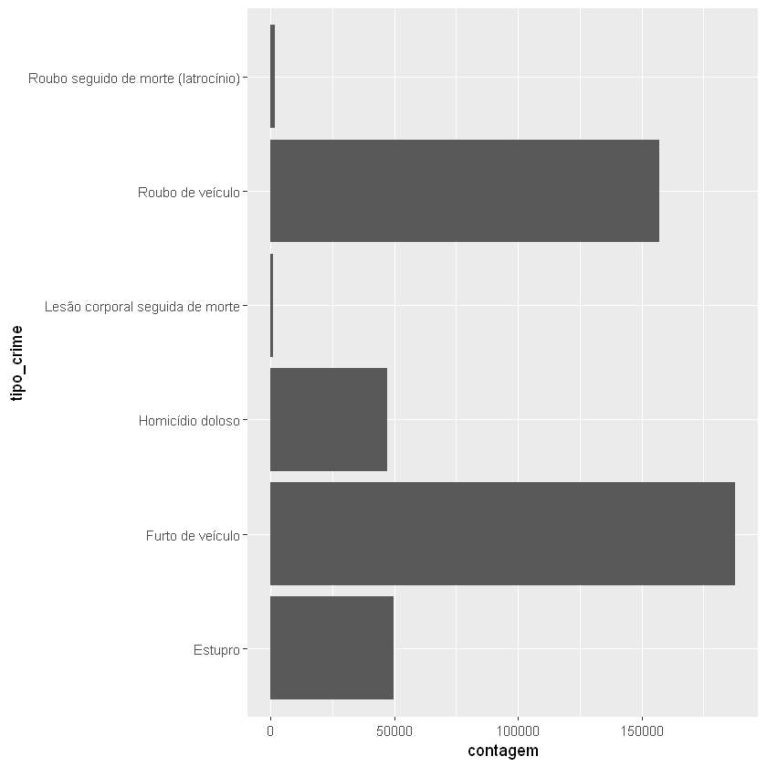

```r
ggplot(tabFreq, aes(tipo_crime, contagem)) + geom_bar(stat = 'identity') + coord_flip();
```

Veja, a interpretação tornou-se mais simples! Agora que sabemos qual foi o crime mais cometido no ano de 2013, vamos decobrir como foi a distribuição destas quantidades de ocorrências nos meses.

### Meses e suas taxas de crimes (2013)

Para obter esta informação, vamos primeiro agrupar os dados levando em consideração os meses, e então, contar as ocorrências de cada crime.

```r
crimeAndMonth <- year2013 %>% group_by(mes, tipo_crime) %>% summarise(contagem=sum(ocorrencias));
head(crimeAndMonth, 3);
```

| mes | tipo_crime | contagem |
| --- | --- | --- |
| 1 | Estupro | 4569.00 |
| 1 | Furto de veículo | 16871.31 |
| 1 | Homicídio doloso | 4148.00 |

No caso destes dados há muitos valores, vamos também criar um plot que facilite a visualização e entendimento dos dados.

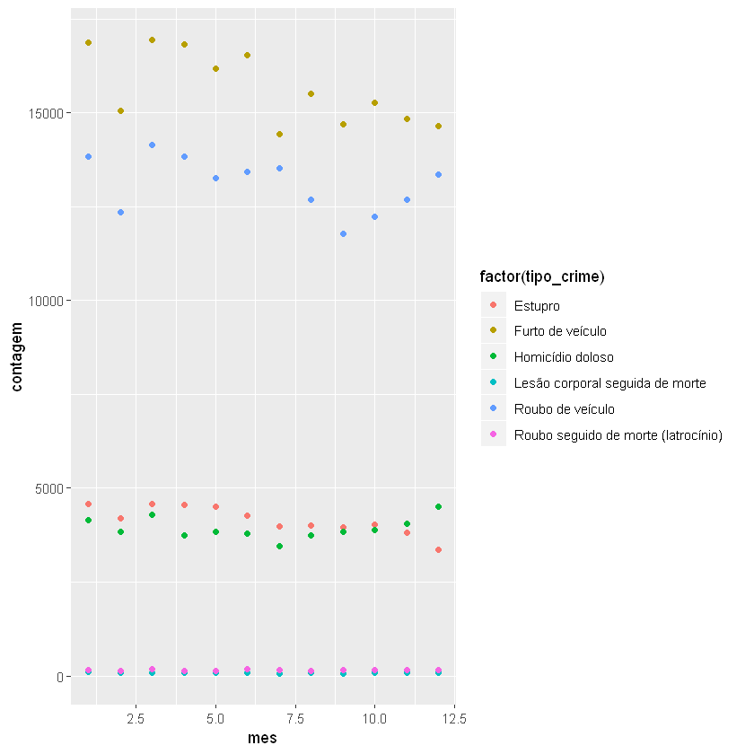

```r
ggplot(crimeAndMonth, aes(x = mes, y = contagem, color = factor(tipo_crime))) + geom_point();
```

Veja que, há um certo padrão na distribuição dos dados, onde certos tipos de crimes apresentam valores muito próximos, aqui, conseguimos perceber por exemplo que, o furto de carro ao longo de todo o ano de 2013 foi muito alto, além ainda de crimes de lesão corporal e estrupo, que mantiveram as mesmas quantidades quase durante o ano todo.

### Crimes por cidade

Vamos agora olhar quais cidades tiveram os maiores índices de cada um dos tipos de crime, no ano de 2013.

```r
crimeAndCity <- year2013 %>% group_by(municipio, tipo_crime) %>% summarise(contagem = sum(ocorrencias));

crimeAndCityMax <- crimeAndCity %>% group_by.crime() %>% summarise(contagem = max(contagem)) %>% inner_join(crimeAndCity);
```

Pronto! Agora os dados estão agrupados levando em consideração os municípios com a maior quantidade de um determinado tipo de crime, vamos criar uma visualização para facilitar o entendimento dos dados.

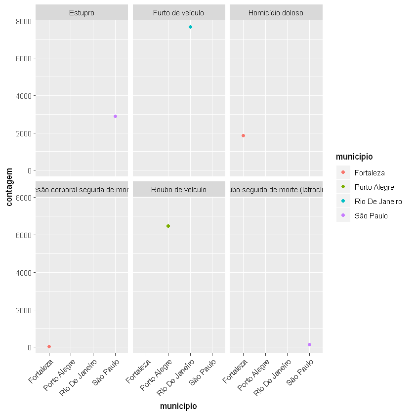

```r
ggplot(crimeAndCityMax, aes(x = municipio, y = contagem, color = municipio)) + geom_point() + facet_wrap(~tipo_crime) + theme(axis.text.x  = element_text(angle = 45, hjust = 1));
```

Com esta visualização é possível entender que, a cidade com maiores registros de estrupo é Sâo Paulo, bem como o Furto de veículo tem as maiores ocorrências no Rio de Janeiro, e assim por diante.

## Expansão temporal da análise

Bom, diante aos dados de um único ano obtivemos diversas informações interessantes, porém, vamos avançar! Vamos entender os fenômenos destes dados ao decorrer dos anos.

> Veja que esta avaliação será possível já que o **SINESPJC** disponibiliza uma base de dados de 2004 até 2017.

Vale lembrar que, caso você queira, é possível baixar estes dados utilizando o script disponível no [Github](https://github.com/M3nin0/ocorrencias-brasil/tree/master/recuperacao_dados).

Vamos começar carregando todos os dados

```r
allYears <- readAllData();
```

```
[1] "ocorrenciasmun-brasil2004.csv"
[1] "ocorrenciasmun-brasil2005.csv"
[1] "ocorrenciasmun-brasil2006.csv"
[1] "ocorrenciasmun-brasil2007.csv"
[1] "ocorrenciasmun-brasil2008.csv"
[1] "ocorrenciasmun-brasil2009.csv"
[1] "ocorrenciasmun-brasil2010.csv"
[1] "ocorrenciasmun-brasil2011.csv"
[1] "ocorrenciasmun-brasil2012.csv"
[1] "ocorrenciasmun-brasil2013.csv"
[1] "ocorrenciasmun-brasil2014.csv"
[1] "ocorrenciasmun-brasil2015.csv"
[1] "ocorrenciasmun-brasil2016.csv"
[1] "ocorrenciasmun-brasil2017.csv"
```

Beleza! Com os dados carregados, vamos novamente visualizar sua estrutura. Este passo é importante para o entendimento dos dados.

```r
head(allYears, 3);
```

| regiao | sigla_uf | uf | cod_uf | municipio | tipo_crime | mes | mes_ano | ocorrencias |
| --- | --- | --- | --- | --- | --- | --- | --- | --- |
| SUDESTE | ES | Espírito Santo | 3201209 | Cachoeiro De Itapemirim | Estupro | 1 | 01/2004 | 1 |
| SUDESTE | ES | Espírito Santo | 3201209 | Cachoeiro De Itapemirim | Estupro | 3 | 03/2004 | 2 |
| SUDESTE | ES | Espírito Santo | 3201209 | Cachoeiro De Itapemirim | Estupro | 5 | 05/2004 | 4 |

```r
tail(allYears, 3);
```

|  | regiao | sigla_uf | uf | cod_uf | municipio | tipo_crime | mes | mes_ano | ocorrencias |
| --- | --- | --- | --- | --- | --- | --- | --- | --- | --- |
| 375443 | SUL | SC | Santa Catarina | NA | Balneário Rincão | Furto de veículo | 2 | 02/2017 | 5 |
| 375444 | SUL | SC | Santa Catarina | NA | Balneário Rincão | Furto de veículo | 6 | 06/2017 | 2 |
| 375445 | SUL | SC | Santa Catarina | NA | Balneário Rincão | Roubo de veículo | 2 | 02/2017 | 1 |

Veja que há uma varição grande nos meses e anos e ainda, que a estrutura base é a mesma dos dados vistos para um único ano (2013), vamos então começar esta nova etapa de análise.

Agora, vou criar uma `linha do tempo` variando com a quantidade total de ocorrências em cada um dos anos presentes no conjunto de dados.

```r
allYears <- allYears %>% rowwise() %>% mutate(ano = as.integer(stringr::str_split(mes_ano, '/')[[1]][2]));
```

Bem, acima apliquei apenas uma função para gerar um coluna com apenas os valores dos anos, vamos agora agrupar os dados pelos anos e então realizar a contagem.

```r
allYearsGroupedByYear <- allYears %>% group_by(ano) %>% summarise(contagem_total = sum(ocorrencias));
```

Com os dados agrupados, vamos realizar o plot para visualizar o resultado.

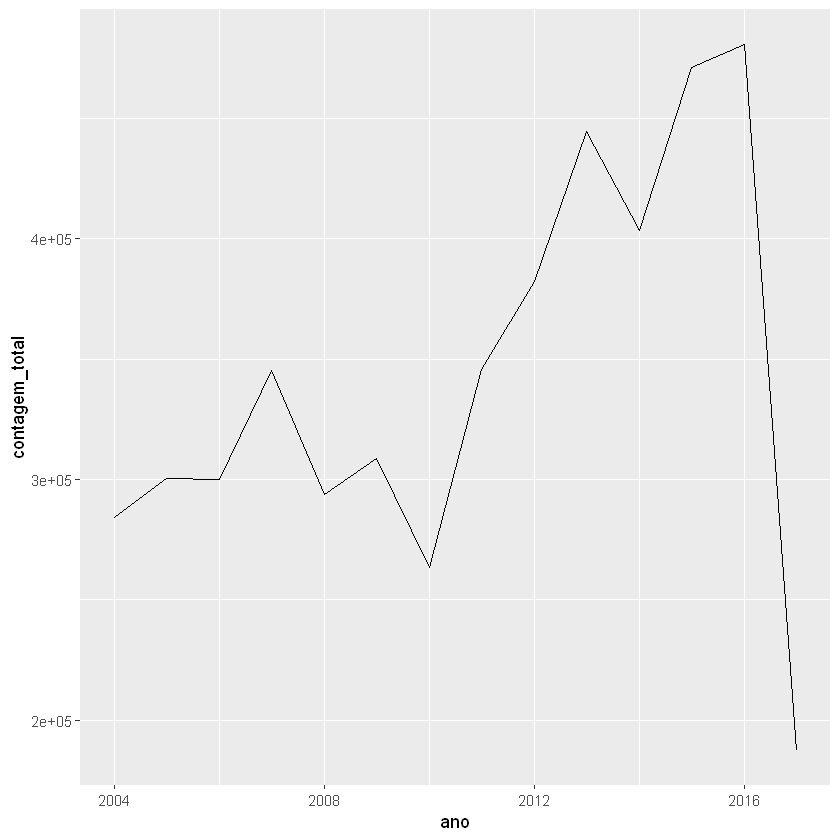

```r
ggplot(allYearsGroupedByYear, aes(ano, contagem_total)) + geom_line();
```

Esta informação é bastante interessante, porém, e com relação a cada um dos crimes ? Qual foi sua variação ao longo dos anos, vamos entender isto agora.

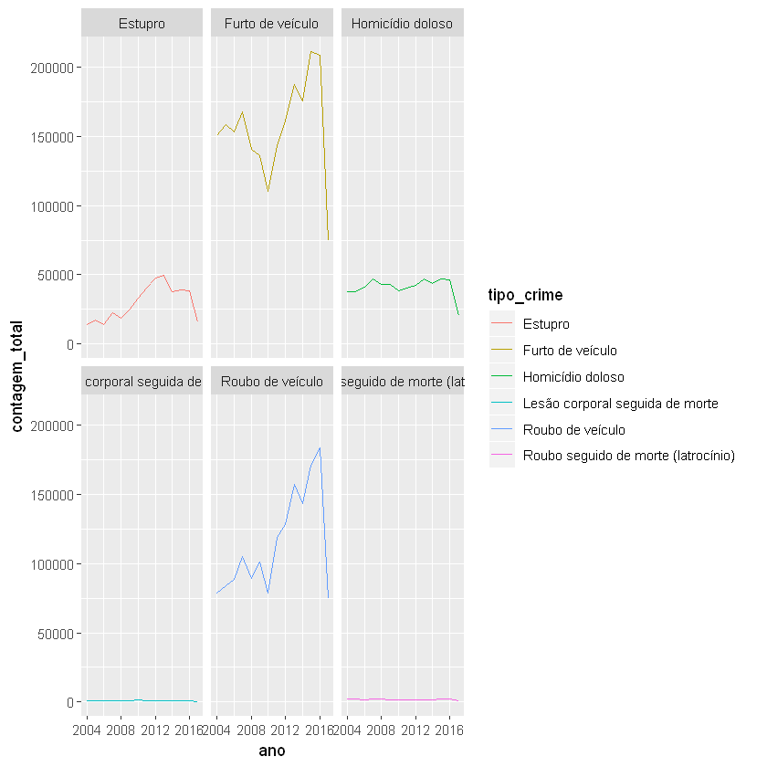

```r
allYersGroupedByYearAndCrime <- allYears %>% group_by(ano, tipo_crime) %>% summarise(contagem_total = sum(ocorrencias));

ggplot(allYersGroupedByYearAndCrime, aes(ano, contagem_total, color = tipo_crime)) + geom_line() + facet_wrap(~ tipo_crime);
```

Veja que interessante, conseguimos visualizar a variação no tempo de cada um dos tipos de crimes, sendo os que mais variam `Furto, Roubo, Estrupo e Homicídio doloso`.

Ao ver este último gráfico, me surgiu a curiosidade de saber qual os anos apresentaram os maiores números de ocorrências para cada um dos crimes. Vamos fazer isto então.

```r
crimeAndYear <- allYears %>% group_by(ano, tipo_crime) %>% summarise(qtd = sum(ocorrencias));
crimeAndYearMax <- crimeAndYear %>% group_by.crime() %>% summarise(qtd = max(qtd)) %>% inner_join(crimeAndYear);
```

Bem acima apenas agrupei os dados, vamos agora realizar o plot para obter as informações de cada um dos anos e seus crimes.

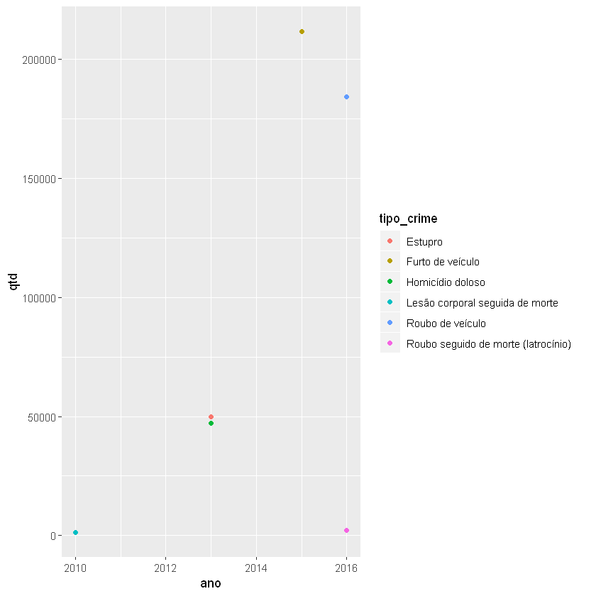

```r
ggplot(crimeAndYearMax, aes(ano, qtd, color = tipo_crime)) + geom_point();
```

Como podemos ver no gráfico acima, para todos os crimes, os maiores índices estão entre 2010 e 2016, o que demonstra que este período de tempo representaram muito mais violência que qualquer outro desde 2004.

É importante nos atentarmos aos crimes de lesão corporal e latrocínio, que em todos os resultados apareceram em baixa, isto pode realmente ocorrer, ou mesmo falta de dados podem estar causando esta característica.